# Introduction to R

Lecture 1

Author

Piero Palacios

# Objectives

- Learn computational modes of thinking.
- Master the art of computational problem solving.
- Make computers do what you want them to do.

# Topics

- Represent knowledge with data structures.
- Iteration.
- Abstraction of procedures and data types.

# What does a computer do?

## Fundamentaly

- Performs calculations really quickly.
- Remember results.

## What kind of calculations?

- Simply arithmetic calculations and logic operations (primitive calculations).

# Types of knowledge

- Declarative knowledge: statement of fact.
- Imperative knowledge: recipe or “how to” (sequence of steps).

## What is a recipe:

Only 3 pieces:

- Sequence of simple steps.
- Flow of control process that specifies when each step is executed.
- A means of determining when to stop.

[figure not shown]

# Computers are machines

- Fixed program machines: calculator, Alan Turing’s Bombe.
- Stored program machines: machines stores and executes instructions.

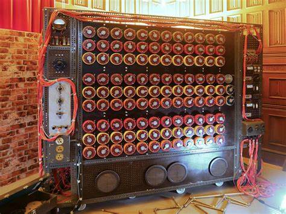

## Stored Program Computer

Sequence of instructions stored inside computer build from predefined set of primitive instructions.

- Arithmetic and logic.
- Simple tests.
- Moving data.

Special program (interpreter: python, R, javascript, matlab, etc) executes each instruction in order

- Use tests to change flow of control through sequence.
- Stop when done.

[figure not shown]

### Basic Primitives

- Alan Turing showed you can compute anything using 6 primitives (left,right,scan,read,write,do nothing).
- Modern programming languages have more convenient set of primitives.
- Can abstract methods to create new primitives.
- **Anything computable in one language is computable in any other programming language** - Touring complete

# Creating Recipes

- A programming language provides a set of primitive operations
- Expressions are complex but legal combinations of primitives in a programming language.
- Expressions and computations have values and meaning in a programming language.

## Aspects of Languages

- Primitive constructs:
  - Spanish: words.
  - programming language: numbers, strings, simple operations.
- Syntax:
  - Spanish: “perro gato arbol” - not syntactically valid “el perro come carne” - syntactically valid
  - programming language: “hi”5 - not syntactically valid 10.7 * 5 - syntactically valid
- Static semantics: Syntactically valid strings have **meaning**.
  - Spanish: “Yo estamos comiendo” - syntactically valid but static semantic error.
  - programming language: 10.7*5 - syntactically valid 3 + “hola” - static semantic error
- Semantics: Is the meaning associated with a syntactically correct string of symbols with no static semantic errors.
  - Spanish: “Volar aviones es dificil” “Usar estadistica es sencillo”
  - programming language: have only one meaning but may not be what programmer intended (bugs) e.g. program stops running, program runs forever, program gives an answer but different than expected.

# Types

## Objects

- Programs manipulate **data objects**.
- Objects have a type that defines the kinds of things programs can do to them.

### Scalar Objects

```r
# int
5
```

```
[1] 5
```

```r
# float
3.59
```

```
[1] 3.59
```

```r
# bool

TRUE
```

```
[1] TRUE
```

```r
# Not a number

NaN
```

```
[1] NaN
```

```r
# use the function typeof to see the type

typeof(TRUE)
```

```
[1] "logical"
```

```r
# we can specify the type

as.integer(5)
```

```
[1] 5
```

```r
as.logical(1)
```

```
[1] TRUE
```

```r
as.double(5)
```

```
[1] 5
```

### Expressions

- Combine objects and operator to form expressions.
- An expression have a value, which has a type.
- Syntax for a simple expression:

[figure not shown]